# Chemical compounds study

Quality Control Report

Author

Paulina Jedynak (paulinaalicja.jedynak@ISGlobal.org)

Published

June 12, 2023

Abstract

Disclaimer: this is a partially invented analysis of simulated data. The presented descriptions or conclusions may not be accurate and may not reflect scientifically correct approach, they have an illustrative purpose only.

1. **Aim**

The aim of the analysis was to assess concentrations of compounds from biological samples collected from a cohort subjects.

2. **Sample size and selection of samples for the analysis**

[figure not shown]

Figure 1: Study flowchart.

3. **Descriptive analysis of compounds**
1. **Limits of detection (LOD) and quantification (LOQ)**

| Compound | n | %<LOD | n<LOD | %<LLOQ | n<LLOQ | %>ULOQ | n>ULOQ |
| --- | --- | --- | --- | --- | --- | --- | --- |
| Compound 1 | 826 | 0.6 | 5 | 0.6 | 5 | 0.1 | 1 |
| Compound 2 | 830 | 0.7 | 6 | 0.7 | 6 | 6.5 | 54 |
| Compound 3 | 830 | 0.2 | 2 | 0.2 | 2 | 1.6 | 13 |
| Compound 4 | 830 | 0.6 | 5 | 0.6 | 5 | 0.1 | 1 |
| Compound 5 | 830 | 0.4 | 3 | 0.4 | 3 | 0.5 | 4 |
| Compound 6 | 830 | 0.4 | 3 | 0.4 | 3 | 0.1 | 1 |
| Compound 7 | 830 | 0.6 | 5 | 1.2 | 10 | 0.0 | 0 |
| Compound 8 | 828 | 3.1 | 26 | 4.1 | 34 | 0.0 | 0 |
| Compound 9 | 830 | 0.2 | 2 | 0.2 | 2 | 70.5 | 585 |

2. **Numerical summary of compounds concentrations**

Table 2: Compounds concentrations.

| Compound | Min | 5% | 25% | Median | Mean | 75% | 95% | Max |
| --- | --- | --- | --- | --- | --- | --- | --- | --- |
| Compound 1 | <LOD | 1.6 | 2.7 | 3.9 | 5.1 | 5.9 | 12.4 | 83.7 |
| Compound 2 | <LOD | 0.3 | 0.6 | 0.9 | 1.5 | 1.6 | 4.3 | 45.3 |
| Compound 3 | <LOD | 2.3 | 3.9 | 5.3 | 6.2 | 7.3 | 12.8 | 101.5 |
| Compound 4 | <LOD | 8.3 | 17.7 | 32.6 | 38.2 | 48.5 | 82.9 | 938.2 |
| Compound 5 | <LOD | 4.6 | 7.8 | 11.4 | 14.3 | 16.3 | 32.8 | 434.4 |
| Compound 6 | <LOD | 2.7 | 5.0 | 7.0 | 8.3 | 9.6 | 16.6 | 177.4 |
| Compound 7 | <LOD | 1.2 | 2.4 | 3.5 | 3.9 | 4.9 | 7.7 | 26.5 |
| Compound 8 | <LOD | 0.2 | 0.3 | 0.5 | 0.7 | 0.9 | 1.8 | 5.6 |
| Compound 9 | <LOD | 49.6 | 125.0 | 228.6 | 381.2 | 438.9 | 1168.8 | 6466.0 |

3. **Compounds missing data**

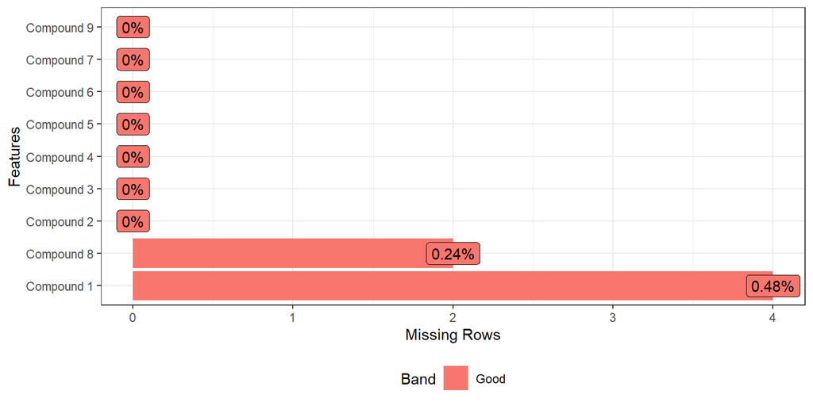

Figure 2: Percentage of missing values per compound.

Only a few values for Compound 8 and Compound 1 were missing (**Figure 2**). There were 7 samples (fakeID1, fakeID2, fakeID3, fakeID4, fakeID5, fakeID6, fakeID7) that were sent to the analytical lab but were not processed (due to too small amount of the sample or sample loss), and so they are not included in the QC report and will not be imputed. As for other samples, there were no missing values except for 2 values for Compound 8 and 4 values for Compound 1 that did not pass the quality control (see above). These values will not be imputed.

4. **Impact of data imputation**

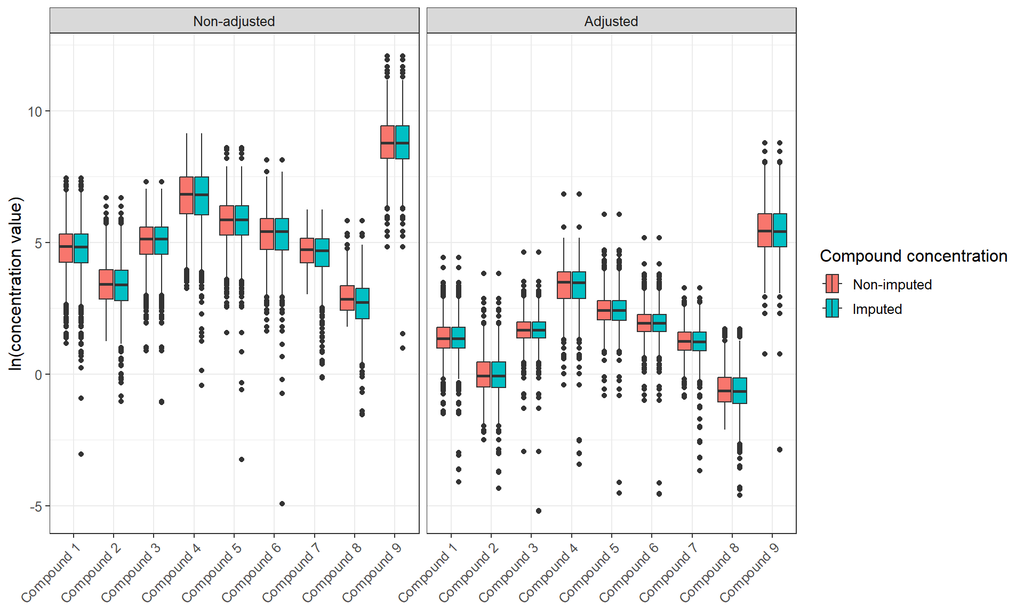

Figure 3: Comparison of ln-transformed non-imputed and imputed values for samples adjusted and unadjusted for weight.

The imputed values ranges look sane.

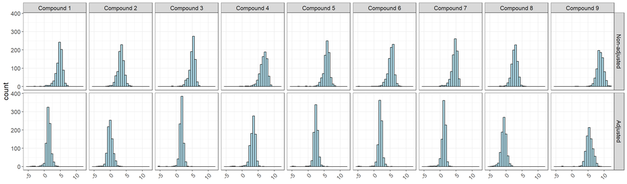

Figure 4: Histograms for imputed compound concentration values for samples adjusted and non-adjusted for weight.

5. **Compounds correlation structure**

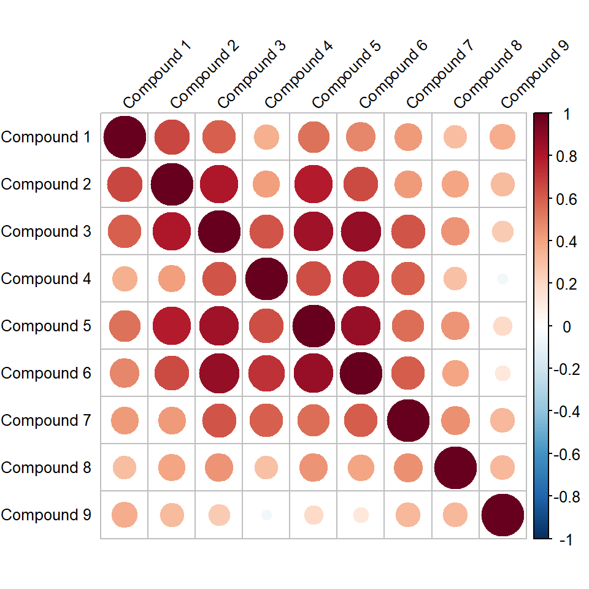

Figure 5: Correlation structure for the compounds.

6. **Outliers**

Out of the final 830 available samples, there were 4 samples that contained outliers due to potential contamination in Compound 1 (fakeID9, fakeID10, fakeID11, fakeID12) and 2 in Compound 8 (fakeID13, fakeID14). These values were indicated by the analytical lab to be removed and we decided to follow this recommendation. These values were not included in the QC report and will not be imputed.

One additional sample (fakeID15) was indicated by the analytical lab as an outlier for all metabolites, due to extremely low concentration of internal standard and this sample was removed prior to the following analyses, was not included in the QC report and will not be imputed.

**PCA - individual contribution**

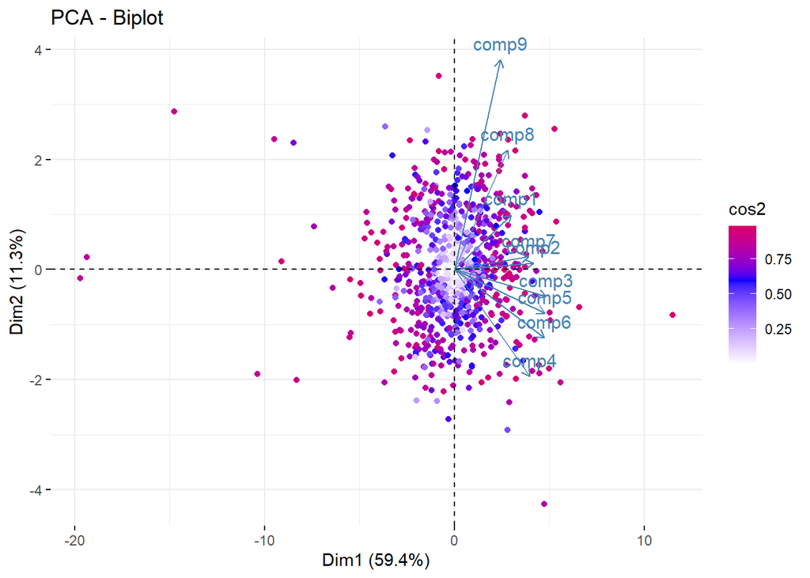

Figure 6: PCA-based individual contribution (the quality of the individuals on the factor map).

**PCA - effect of covariates**

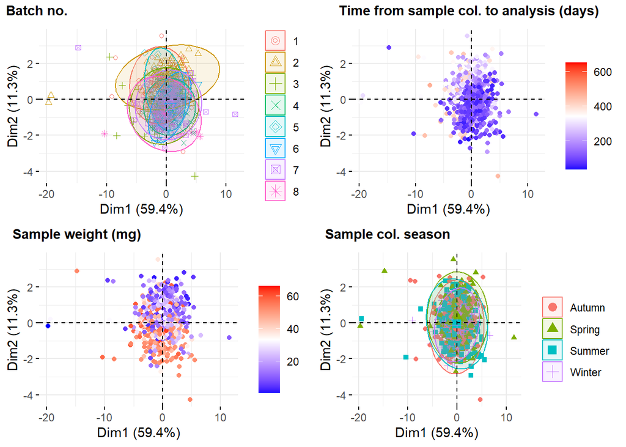

Figure 7: PCA analysis with potentially influential factors overlapped.

**Exploration of the sample weight effect**

**Visual inspection of associations between compound concentrations and sample weight**

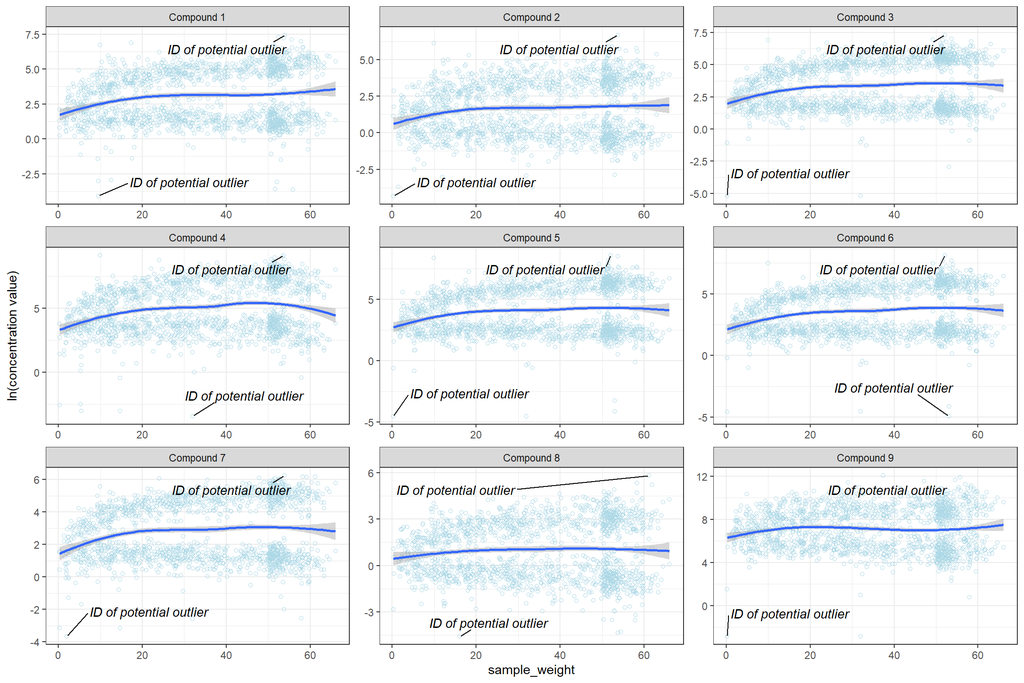

Figure 8: Fitted associations between compounds’ concentrations and sample weight.

fakeID18 seems like an outlier (**Figure 8**), but visual inspection is not accurate in this case. Analytical lab did not detect any reasons for these, so most probably this is a biological and not technical outlier. We recommend sensitivity analysis without this sample.

**Numerical analysis of the linear effects and correlation between compound concentrations and sample weight**

Table 3: Regression estimates for single linear regressions with sample weight predicting compound concentrations. Only estimates for associations with p-value for overall effect <0.1 or linear association p-value < 0.1 were displayed.

| Compound | Estimate (CI) | Overall p-val. | rho |
| --- | --- | --- | --- |
| Compound 1 | 0.02 (0.01; 0.02) | 0.00 | 0.15 |
| Compound 2 | 0.01 (0.01; 0.02) | 0.00 | 0.10 |
| Compound 3 | 0.02 (0.01; 0.02) | 0.00 | 0.15 |
| Compound 4 | 0.02 (0.02; 0.03) | 0.00 | 0.17 |
| Compound 5 | 0.02 (0.01; 0.02) | 0.00 | 0.14 |
| Compound 6 | 0.02 (0.01; 0.02) | 0.00 | 0.18 |
| Compound 7 | 0.02 (0.01; 0.02) | 0.00 | 0.13 |
| Compound 8 | 0.01 (0; 0.01) | 0.02 | 0.04 |

## Bibliography

Author. 2021. “Title of the Publication.” *J Chromatogr A* 1624 (August): 24534654.